# Data Exploration

Madelyn Subali

5/7/2022

# Introduction

The College Scorecard is a public-facing website that contains important information about colleges, including how much its graduates earn. Here, I will discuss on how the Scorecard shifted interest between high- and low-earnings colleges over the year.

The College Scorecard was released at the start of September 2015. The report will show if colleges that predominantly grant Bachelor’s degrees, on the release of the Scorecard shift student’s interest to high-earnings colleges relative to low-earnings ones.

# Data Cleaning

```r
# Libraries
library(tidyverse)
library(fixest)
library(ggstance)
library(vtable)
library(multcomp)
library(purrr)
library(lubridate)
```

```r
library(dplyr)
library(jtools)

#Reading in Google Trends Data
trends_files <- list.files(path = '.' , pattern='trends_', full.names=TRUE)
trends_files <- map_df(trends_files, read_csv)
#Aggregating the Google Trends Data:
trends_files <- trends_files %>%
   group_by(schname, keyword) %>%
  mutate(index_id = (index - mean(index, na.rm=TRUE)) /sd(index, na.rm=TRUE))

# Reading in Scorecard Data
score <- read_csv('Most+Recent+Cohorts+(Scorecard+Elements).csv')
id_name_link <- read_csv('id_name_link.csv')
# Remove university that share the same schname
id_name_link <- id_name_link %>%
  group_by(schname) %>%
  mutate(n= n()) %>%
  filter ( n == 1)

# Make column name to lower case to match with id_name_link file
names(score) <- tolower(names(score))

# Merging the scorecard data
join_files <- inner_join(id_name_link, trends_files, by='schname')
final_join <- inner_join(join_files, score, by='unitid')
write_csv(final_join, "clean_data.csv")
```

# Analysis

According to a 2020 data retrieved from Northeastern University, the median weekly earnings of someone with a Bachelor’s degree working in the United States is $1,248 with an annual earnings of $64,896. With this in mind, I will make $64,896 as a benchmark. Colleges with a median annual earning of $64,896 or higher will be marked as high-earning colleges and below $64,896 as low-earning colleges.

```r
# Filter college for Bachelor's degree and removing NA values.
clean_data <- read_csv('clean_data.csv')
bachelors_degree_trend <- clean_data %>% filter(preddeg == 3, na.rm=TRUE)
```

Creating dummy variables with ifelse() function to set the benchmark, where ‘1’ is high-earning and ‘0’ is low-earning.

```r
bachelors_degree_trend$medianEarning <- ifelse(bachelors_degree_trend$`md_earn_wne_p10-reported-earnings` >= 64896, '1', '0')
```

Selecting only the necessary columns that we want to use in our data set.

```r
bachelors_degree_trend <- bachelors_degree_trend %>%
                          dplyr::select(unitid, opeid.x, instnm, city, monthorweek, preddeg, sat_avg, ugds, `md_earn_wne_p10-reported-earnings`, medianEarning, index_id) %>%
                          mutate(date= as.Date(str_sub(monthorweek, 1,10))) %>%
                          group_by(month = floor_date(date, "month"), medianEarning) %>%
                          summarize(index_id = mean(index_id, na.rm = TRUE))
```

# Regression

According to the US department of education, the college scorecard was launched on September 12,2015. The regression below is going to test whether there is an impact on Google Trends index on median earnings, before and after the college scorecard was launched.

```r
clean_data <- clean_data %>%
  mutate(earning = `md_earn_wne_p10-reported-earnings` >= 64896, post_scorecard = monthorweek >=
           as.Date("2015-09-12"))

m1 <- feols(index_id ~ earning*post_scorecard, data=clean_data)
```

```
## NOTE: 8,475 observations removed because of NA values (LHS: 8,475, RHS: 7,583).
```

```r
export_summs(m1, digits = 3)
```

|  | Model 1 |
| --- | --- |
| (Intercept) | 0.056 *** |
|  | (0.001) |
| earningTRUE | 0.003 |
|  | (0.003) |
| post_scorecardTRUE | -0.306 *** |
|  | (0.002) |
| earningTRUE:post_scorecardTRUE | -0.019 * |
|  | (0.007) |
| nobs | 1525949 |
| r.squared | 0.014 |
| adj.r.squared | 0.014 |
| within.r.squared |  |
| pseudo.r.squared |  |
| sigma | 0.990 |
| nobs.1 | 1525949.000 |
| AIC | 4298819.455 |
| BIC | 4298868.408 |
| logLik | -2149405.728 |
| *** p < 0.001; ** p < 0.01; * p < 0.05. |  |

# Visualization

The visualization below will show the impacts of Google Trends index within the years of high-earning and low-earning colleges. Here, high-earning is depicted as ‘1’, while low-earning is depicted as ‘0’.

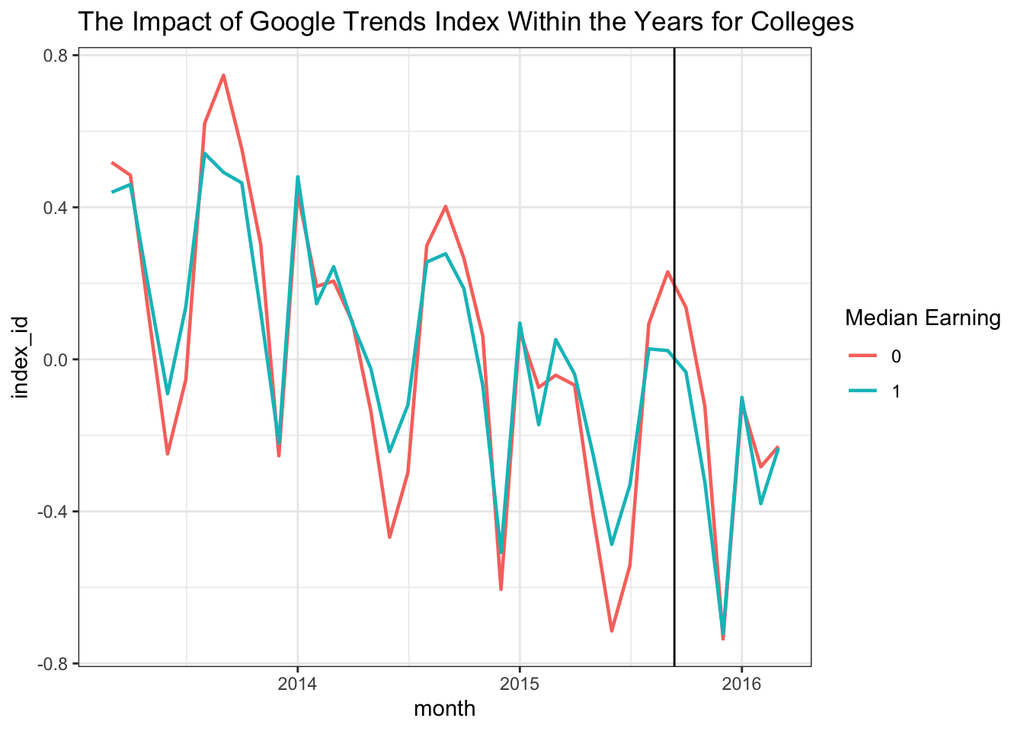